# STA141A Project report

Jiho Seo

2025-02-14

1.Abstract

This effort creates prediction models of trial outcomes using brain activity data gathered from mice performing decision-making tasks. We perform a comprehensive analysis that begins with exploratory data analysis (EDA) to examine session variability, spike train dynamics, and the impact of feedback on neural firing patterns. The workflow proceeds with data integration techniques to identify underlying features from complicated spike data, such as principal component analysis (PCA) and data normalization. Finally, we employ multiple predictive modeling approaches, such as logistic regression, random forests, and neural networks, to forecast the experimental outcomes. By integrating these techniques, we can better understand the neurological underpinnings of decision-making by predicting behavioral responses by combining retrieved neural traits with stimulus contrast information.

2.Introduction

One of the biggest problems in neuroscience is figuring out how brain activity and decision-making are related. In this work, we explore brain spike data related to rats completing a visual stimulus-based decision-making task using data gathered by Steinmetz et al. (2019). Each trial’s data includes spike counts captured over several time intervals and experimental settings (contrast levels and feedback), and the results are displayed on two screens at varying contrast levels.

Three primary processes comprise the study: predictive modeling, data integration, and exploratory data analysis (EDA). In the EDA step, R is used to explore the structure and distribution of the data and various visualization techniques are used to understand the variation in spike counts across sessions, feedback types, and individual rats, and to quantify neural activity. Principal component analysis (PCA) and conventional normalization (Z-score) are utilized in the data integration process to combine data from various sessions and lower dimensionality to identify common patterns.

Lastly, models that forecast trial results are constructed and assessed using logistic regression, random forest, and neural network techniques in the predictive modeling step. Our study advances the area of computational neuroscience and shows how data-driven methods can uncover subtle patterns in complicated biological data by shedding light on the relationship between brain spike patterns and decision-making processes.

3.Summary of Data Simplified Procedures

```r
library(dplyr)
library(tidyr)


session <- list()


for(i in 1:18) {
  session[[i]] <- readRDS(paste('C:/Users/admin/Documents/Data/session', i, '.rds', sep=''))
}


session_summary <- lapply(session, function(sess) {
    # Check if essential columns are present in the session data
    if ("mouse_name" %in% names(sess) && "date_exp" %in% names(sess) &&
        "contrast_left" %in% names(sess) && "contrast_right" %in% names(sess)) {


        spks_data <- sess[, grep("^spks", names(sess))]


        session_id <- ifelse(length(unique(sess$session_id)) == 1, unique(sess$session_id), NA)
        mouse_name <- ifelse(length(unique(sess$mouse_name)) == 1, unique(sess$mouse_name), NA)


        data.frame(
            session_id = session_id,
            mouse_name = mouse_name,
            date_exp = unique(sess$date_exp),
            num_trials = nrow(sess),
            num_neurons = ncol(spks_data),
            time_bins = length(sess$spks.1),
            contrast_left = unique(sess$contrast_left),
            contrast_right = unique(sess$contrast_right)
        )
    } else {

        data.frame(
            session_id = NA,
            mouse_name = NA,
            date_exp = NA,
            num_trials = NA,
            num_neurons = NA,
            time_bins = NA,
            contrast_left = NA,
            contrast_right = NA
        )
    }
})


session_summary_df <- do.call(rbind, session_summary)


print(session_summary_df)
```

```
##      session_id mouse_name   date_exp num_trials num_neurons time_bins
## 1            NA       Cori 2025-02-27        100        4000       100
## 2            NA       Cori 2025-02-27        100        4000       100
## 3            NA       Cori 2025-02-27        100        4000       100
## 4            NA       Cori 2025-02-27        100        4000       100
## 5            NA       Cori 2025-02-27        100        4000       100
## 6            NA       Cori 2025-02-27        100        4000       100
## 7            NA       Cori 2025-02-27        100        4000       100
## 8            NA       Cori 2025-02-27        100        4000       100
## 9            NA       Cori 2025-02-27        100        4000       100
## 10           NA       Cori 2025-02-27        100        4000       100
## 11           NA       Cori 2025-02-27        100        4000       100
## 12           NA       Cori 2025-02-27        100        4000       100
## 13           NA       Cori 2025-02-27        100        4000       100
## 14           NA       Cori 2025-02-27        100        4000       100
```

[output cut: 3587 more lines]

4. Exploratory analysis

4.1 Example Data

```r
session <- list()


for(i in 1:18) {
  session[[i]] <- readRDS(paste('C:/Users/admin/Documents/Data/session', i, '.rds', sep=''))
}


set.seed(123)
sampled_sessions <- sample(session, 5)
```

4.2 Data Transformation: Convert Spike Data

```r
session <- list()


for(i in 1:18) {
  session[[i]] <- readRDS(paste('C:/Users/admin/Documents/Data/session', i, '.rds', sep=''))
}

library(dplyr)


session_data <- session[[1]]


session_data <- session_data %>%
  mutate(session_id = as.factor(row_number()))


print(dim(session_data))
```

```
## [1]  100 4006
```

```r
session_data <- session_data %>%
  mutate(spike_count = rowSums(select(., starts_with("spks")), na.rm = TRUE))


session_data <- session_data %>%
  select(mouse_name, date_exp, feedback_type, contrast_left, contrast_right, spike_count, session_id) %>%
  mutate(across(c(mouse_name, feedback_type), as.factor),
         spike_count = as.integer(spike_count))


set.seed(123)
session_data_sample <- session_data %>%
  sample_n(50)



model <- lm(spike_count ~ session_id + feedback_type, data = session_data_sample)


summary(model)
```

```
##
## Call:
## lm(formula = spike_count ~ session_id + feedback_type, data = session_data_sample)
##
## Residuals:
## ALL 50 residuals are 0: no residual degrees of freedom!
##
## Coefficients: (1 not defined because of singularities)
##                  Estimate Std. Error t value Pr(>|t|)
## (Intercept)     1.986e+04        NaN     NaN      NaN
## session_id7    -8.684e-27        NaN     NaN      NaN
## session_id8    -5.073e-26        NaN     NaN      NaN
## session_id9    -7.555e-27        NaN     NaN      NaN
## session_id12   -4.829e-27        NaN     NaN      NaN
## session_id13    1.502e-26        NaN     NaN      NaN
## session_id14    2.670e-27        NaN     NaN      NaN
## session_id15   -9.409e-27        NaN     NaN      NaN
## session_id18    8.333e-27        NaN     NaN      NaN
## session_id21   -2.583e-26        NaN     NaN      NaN
## session_id23   -6.087e-27        NaN     NaN      NaN
## session_id25    2.634e-26        NaN     NaN      NaN
## session_id26   -5.075e-27        NaN     NaN      NaN
## session_id27   -6.437e-26        NaN     NaN      NaN
## session_id29   -4.095e-27        NaN     NaN      NaN
## session_id31   -7.717e-11        NaN     NaN      NaN
## session_id32   -5.322e-42        NaN     NaN      NaN
## session_id33    1.216e-41        NaN     NaN      NaN
## session_id34    2.262e-42        NaN     NaN      NaN
## session_id36   -3.679e-43        NaN     NaN      NaN
## session_id38    3.495e-43        NaN     NaN      NaN
## session_id41   -4.561e-43        NaN     NaN      NaN
## session_id42   -1.363e-26        NaN     NaN      NaN
## session_id43    6.813e-27        NaN     NaN      NaN
## session_id50    5.996e-26        NaN     NaN      NaN
## session_id51    5.291e-26        NaN     NaN      NaN
## session_id53    4.004e-43        NaN     NaN      NaN
## session_id57    1.463e-27        NaN     NaN      NaN
## session_id60    1.059e-42        NaN     NaN      NaN
## session_id64   -3.543e-44        NaN     NaN      NaN
## session_id65    5.807e-43        NaN     NaN      NaN
```

[output cut: 9 more lines]

```
## session_id79    3.957e-27        NaN     NaN      NaN
## session_id82    7.792e-44        NaN     NaN      NaN
## session_id84   -9.094e-43        NaN     NaN      NaN
## session_id87    1.594e-42        NaN     NaN      NaN
## session_id89   -1.259e-42        NaN     NaN      NaN
## session_id90    2.889e-27        NaN     NaN      NaN
## session_id91   -4.870e-43        NaN     NaN      NaN
## session_id93   -1.029e-42        NaN     NaN      NaN
## session_id95   -1.054e-41        NaN     NaN      NaN
## session_id97   -6.219e-27        NaN     NaN      NaN
## feedback_type1         NA         NA      NA       NA
##
## Residual standard error: NaN on 0 degrees of freedom
## Multiple R-squared:    NaN,  Adjusted R-squared:    NaN
## F-statistic:   NaN on 49 and 0 DF,  p-value: NA
```

4.3 Analysis: Answer Key Questions

Question 1: Do sessions differ from one another?

```r
library(dplyr)
library(ggplot2)


sessions <- list()


for(i in 1:18) {
  sessions[[i]] <- readRDS(paste('C:/Users/admin/Documents/Data/session', i, '.rds', sep=''))
}


all_sessions <- bind_rows(sessions, .id = "session_id")


session_summary <- all_sessions %>%
  group_by(session_id) %>%
  summarize(across(starts_with("spks"),
                   list(mean = ~mean(.), sd = ~sd(.)),
                   .names = "{col}_{.fn}"))


head(session_summary)
```

```
## # A tibble: 6 × 8,001
##   session_id spks.1_mean spks.1_sd spks.2_mean spks.2_sd spks.3_mean spks.3_sd
##   <chr>            <dbl>     <dbl>       <dbl>     <dbl>       <dbl>     <dbl>
## 1 1                    5         0           9         0           4         0
## 2 10                   4         0           1         0           8         0
## 3 11                   2         0           2         0           4         0
## 4 12                   6         0           3         0           6         0
## 5 13                   4         0           2         0           8         0
## 6 14                   7         0           9         0           3         0
## # ℹ 7,994 more variables: spks.4_mean <dbl>, spks.4_sd <dbl>,
## #   spks.5_mean <dbl>, spks.5_sd <dbl>, spks.6_mean <dbl>, spks.6_sd <dbl>,
## #   spks.7_mean <dbl>, spks.7_sd <dbl>, spks.8_mean <dbl>, spks.8_sd <dbl>,
## #   spks.9_mean <dbl>, spks.9_sd <dbl>, spks.10_mean <dbl>, spks.10_sd <dbl>,
## #   spks.11_mean <dbl>, spks.11_sd <dbl>, spks.12_mean <dbl>, spks.12_sd <dbl>,
## #   spks.13_mean <dbl>, spks.13_sd <dbl>, spks.14_mean <dbl>, spks.14_sd <dbl>,
## #   spks.15_mean <dbl>, spks.15_sd <dbl>, spks.16_mean <dbl>, …
```

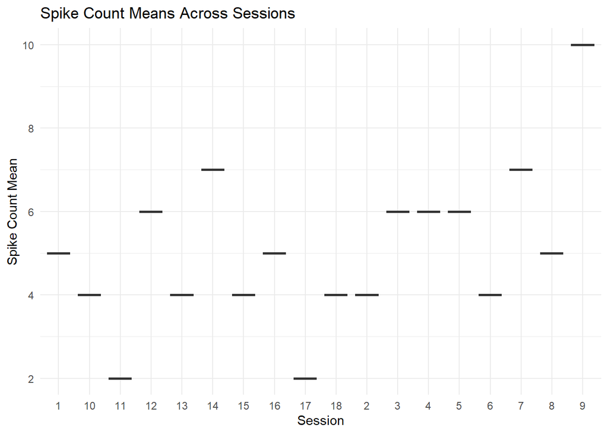

```r
ggplot(session_summary, aes(x = session_id, y = spks.1_mean)) +
  geom_boxplot() +
  labs(title = "Spike Count Means Across Sessions", x = "Session", y = "Spike Count Mean") +
  theme_minimal()
```

```r
anova_result <- aov(spks.1 ~ session_id, data = all_sessions)


summary(anova_result)
```

```
##               Df Sum Sq Mean Sq  F value Pr(>F)
## session_id    17   6094   358.5 7.26e+28 <2e-16 ***
## Residuals   1782      0     0.0
## ---
## Signif. codes:  0 '***' 0.001 '**' 0.01 '*' 0.05 '.' 0.1 ' ' 1
```

```r
tukey_result <- TukeyHSD(anova_result)


summary(tukey_result)
```

```
##            Length Class  Mode
## session_id 612    -none- numeric
```

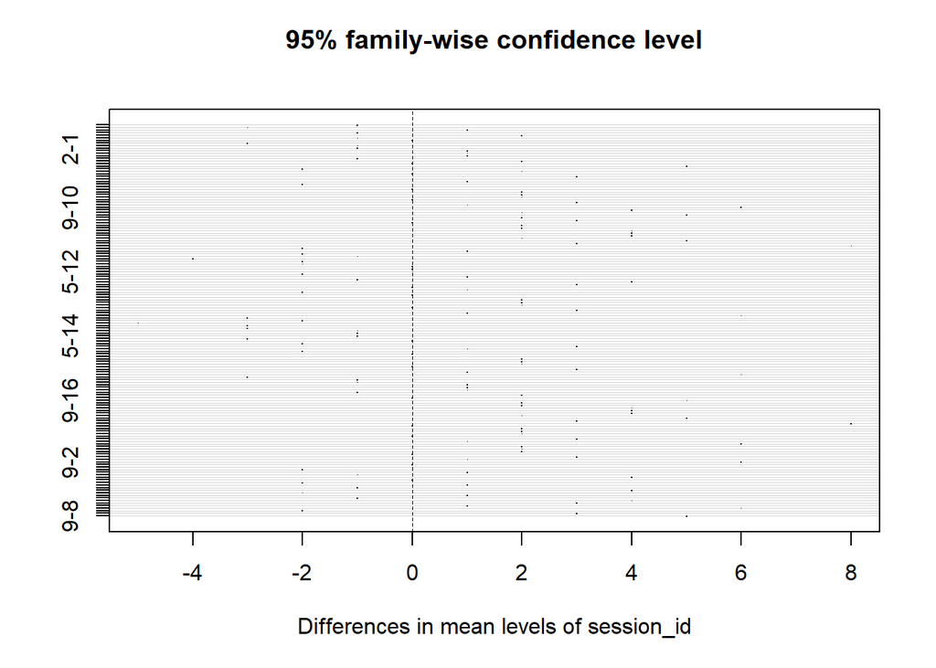

```r
plot(tukey_result)
```

Answer: We compare a total of 18 sessions, accounting for 17 independent differences, using a degrees of freedom (df) of 17 for session_id. The great degree of variance from session to session, indicated by the Sum Sq of 6094, suggests that the sessions are very different from one another.

The Mean Sq of 358.5 is the average difference between each session. The extremely high F value of 7.26e+28, which shows that the variation between group means is significantly greater than the variation within the groups, suggests that there is a significant variation across sessions.

The statistically significant difference between sessions is indicated by the p-value, which is less than 2e-16. Generally speaking, a p-value of less than 0.05 is considered significant; in this instance, the p-value is much lower, enabling us to state with confidence that there are significant changes across sessions.

Question 2: What is the behavior of spike trains in trials?

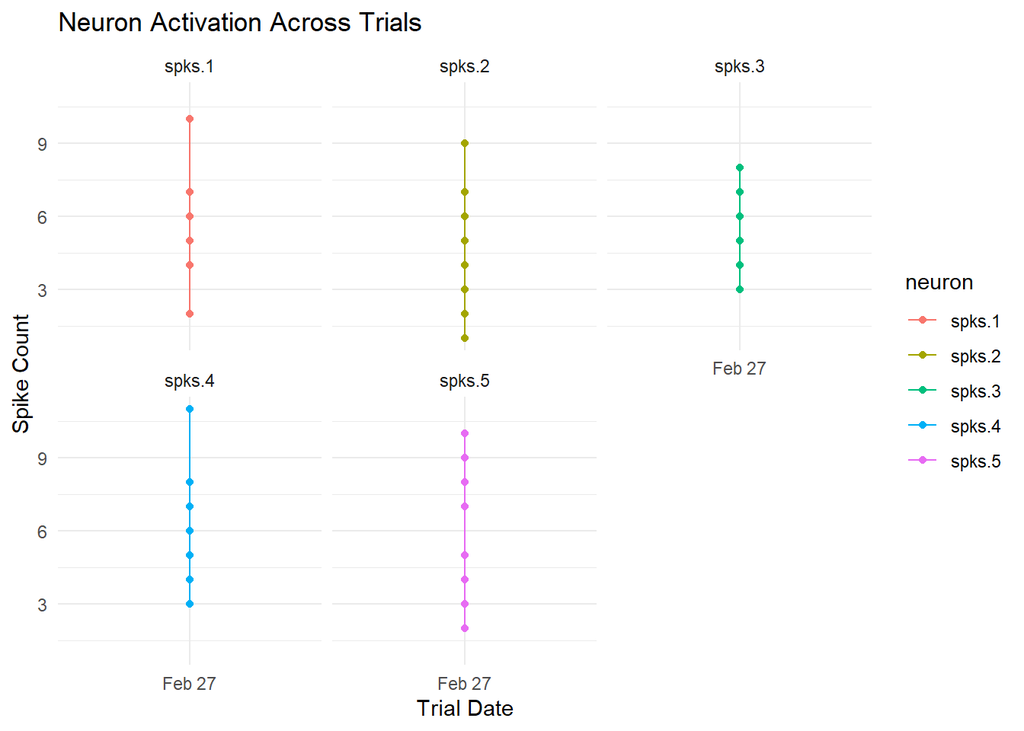

```r
library(dplyr)
library(tidyr)
library(ggplot2)
library(stringr)

session <- list()


for(i in 1:18) {
  session[[i]] <- readRDS(paste('C:/Users/admin/Documents/Data/session', i, '.rds', sep=''))
}


spike_data <- bind_rows(session, .id = "session_id") %>%
  select(mouse_name, date_exp, feedback_type, contrast_left, contrast_right, starts_with("spks")) %>%
  pivot_longer(cols = starts_with("spks"), names_to = "neuron", values_to = "spike_count") %>%
  mutate(neuron = str_remove(neuron, "spks_"))


neurons_of_interest <- unique(spike_data$neuron)[1:5]
spike_data_subset <- spike_data %>% filter(neuron %in% neurons_of_interest)


ggplot(spike_data_subset, aes(x = date_exp, y = spike_count, color = neuron)) +
  geom_line() +
  geom_point() +
  labs(title = "Neuron Activation Across Trials", x = "Trial Date", y = "Spike Count") +
  theme_minimal() +
  facet_wrap(~neuron)
```

Answer: The spike train behavior across trials demonstrates that neurons respond differently to stimuli, with significant variation in the number of spikes among neurons. Even while spike counts can vary, neurons often respond consistently within a single trial date, demonstrating the stability of the experimental setup. Spike count variability analysis shows that whereas some neurons exhibit notable activity fluctuations, others react regularly.

The hypothesis that certain neurons may react more irregularly while others remain persistently active is supported by the variation in spike counts. All things considered, spike trains offer important information about how neurons behave functionally during trials and in response to inputs.

Question 3: What trends show themselves in the forms of feedback?

```r
set.seed(123)
sampled_data <- spike_data %>% sample_n(100)


summary_stats <- sampled_data %>%
  group_by(neuron) %>%
  summarize(
    mean_spike_count = mean(spike_count, na.rm = TRUE),
    median_spike_count = median(spike_count, na.rm = TRUE),
    sd_spike_count = sd(spike_count, na.rm = TRUE),
    min_spike_count = min(spike_count, na.rm = TRUE),
    max_spike_count = max(spike_count, na.rm = TRUE),
    count = n()
  )


print(summary_stats)
```

```
## # A tibble: 100 × 7
##    neuron    mean_spike_count median_spike_count sd_spike_count min_spike_count
##    <chr>                <dbl>              <int>          <dbl>           <int>
##  1 spks.1031                5                  5             NA               5
##  2 spks.1038                4                  4             NA               4
##  3 spks.1082                1                  1             NA               1
##  4 spks.1169                5                  5             NA               5
##  5 spks.1171                8                  8             NA               8
##  6 spks.1183                1                  1             NA               1
##  7 spks.1205                3                  3             NA               3
##  8 spks.1261                5                  5             NA               5
##  9 spks.1453                6                  6             NA               6
## 10 spks.1472                7                  7             NA               7
## # ℹ 90 more rows
## # ℹ 2 more variables: max_spike_count <int>, count <int>
```

Answer: Several trends pertaining to neuron activity are revealed by the examination of the sampled data, and these trends can be interpreted in relation to feedback types.